# Machine Learning Project

### Company Bankruptcy Prediction

Names:

```
- Denis Mugisha
- Liu Guangqiang
- Rachel Fanti
```

Dataset: https://www.kaggle.com/fedesoriano/company-bankruptcy-prediction

Data: May/2021

## Libraries

```python
# Basics
%matplotlib inline
import matplotlib.pyplot as plt
import numpy as np
import pandas as pd
import seaborn as sns
```

```python
# Statistic funtions
from numpy.random import seed
from collections import Counter
```

```python
# Preprocessing
from sklearn.preprocessing import StandardScaler
from sklearn.model_selection import train_test_split

# Select Features
from sklearn.tree import DecisionTreeClassifier
from sklearn.feature_selection import SelectFromModel
from sklearn.feature_selection import RFECV
```

```python
# Neural Network
import sklearn
from sklearn.model_selection import GridSearchCV
from sklearn.neural_network import MLPClassifier
from sklearn.neural_network import MLPRegressor
```

```python
# Evaluation of the model
from sklearn.metrics import classification_report,confusion_matrix
from sklearn.model_selection import learning_curve
from sklearn.metrics import mean_squared_error
# from math import sqrt
```

## Reading data

```python
# Reading the file
# Checking separators, head, nan data (blank) and rows to skip,
# Checking number of total rows (similar to the CSV file)
# Verifying df.head(), df.tail()

df = pd.read_csv('./data/data.csv', sep = ",")
```

## Exploratory analysis of the dataset

```python
df.head()
```

|  | Bankrupt? | ROA(C) before interest and depreciation before interest | ROA(A) before interest and % after tax | ROA(B) before interest and depreciation after tax | Operating Gross Margin | Realized Sales Gross Margin | Operating Profit Rate | Pre-tax net Interest Rate | After-tax net Interest Rate | Non-industry income and expenditure/revenue | ... | Net Income to Total Assets | Total assets to GNP price | No-credit Interval | Gross Profit to Sales | Net Income to Stockholder's Equity | Liability to Equity | Degree of Financial Leverage (DFL) | Interest Coverage Ratio (Interest expense to EBIT) | Net Income Flag | Equity to Liability |
| --- | --- | --- | --- | --- | --- | --- | --- | --- | --- | --- | --- | --- | --- | --- | --- | --- | --- | --- | --- | --- | --- |
| 0 | 1 | 0.370594 | 0.424389 | 0.405750 | 0.601457 | 0.601457 | 0.998969 | 0.796887 | 0.808809 | 0.302646 | ... | 0.716845 | 0.009219 | 0.622879 | 0.601453 | 0.827890 | 0.290202 | 0.026601 | 0.564050 | 1 | 0.016469 |
| 1 | 1 | 0.464291 | 0.538214 | 0.516730 | 0.610235 | 0.610235 | 0.998946 | 0.797380 | 0.809301 | 0.303556 | ... | 0.795297 | 0.008323 | 0.623652 | 0.610237 | 0.839969 | 0.283846 | 0.264577 | 0.570175 | 1 | 0.020794 |
| 2 | 1 | 0.426071 | 0.499019 | 0.472295 | 0.601450 | 0.601364 | 0.998857 | 0.796403 | 0.808388 | 0.302035 | ... | 0.774670 | 0.040003 | 0.623841 | 0.601449 | 0.836774 | 0.290189 | 0.026555 | 0.563706 | 1 | 0.016474 |
| 3 | 1 | 0.399844 | 0.451265 | 0.457733 | 0.583541 | 0.583541 | 0.998700 | 0.796967 | 0.808966 | 0.303350 | ... | 0.739555 | 0.003252 | 0.622929 | 0.583538 | 0.834697 | 0.281721 | 0.026697 | 0.564663 | 1 | 0.023982 |
| 4 | 1 | 0.465022 | 0.538432 | 0.522298 | 0.598783 | 0.598783 | 0.998973 | 0.797366 | 0.809304 | 0.303475 | ... | 0.795016 | 0.003878 | 0.623521 | 0.598782 | 0.839973 | 0.278514 | 0.024752 | 0.575617 | 1 | 0.035490 |

5 rows × 96 columns

```python
# Verifying the type of each column
df.info()
```

```
<class 'pandas.core.frame.DataFrame'>
RangeIndex: 6819 entries, 0 to 6818
Data columns (total 96 columns):
 #   Column                                                    Non-Null Count  Dtype
---  ------                                                    --------------  -----
 0   Bankrupt?                                                 6819 non-null   int64
 1    ROA(C) before interest and depreciation before interest  6819 non-null   float64
 2    ROA(A) before interest and % after tax                   6819 non-null   float64
 3    ROA(B) before interest and depreciation after tax        6819 non-null   float64
 4    Operating Gross Margin                                   6819 non-null   float64
 5    Realized Sales Gross Margin                              6819 non-null   float64
 6    Operating Profit Rate                                    6819 non-null   float64
 7    Pre-tax net Interest Rate                                6819 non-null   float64
 8    After-tax net Interest Rate                              6819 non-null   float64
 9    Non-industry income and expenditure/revenue              6819 non-null   float64
```

[output cut: 88 more lines]

```python
# pd.set_option('display.max_rows', None)
df.isnull().sum().sum()
```

```
0
```

```python
# checking for dulicates??
df.duplicated().sum()
```

```
0
```

```python
pd.set_option('display.max_columns', None)
df.describe()
```

|  | Bankrupt? | ROA(C) before interest and depreciation before interest | ROA(A) before interest and % after tax | ROA(B) before interest and depreciation after tax | Operating Gross Margin | Realized Sales Gross Margin | Operating Profit Rate | Pre-tax net Interest Rate | After-tax net Interest Rate | Non-industry income and expenditure/revenue | Continuous interest rate (after tax) | Operating Expense Rate | Research and development expense rate | Cash flow rate | Interest-bearing debt interest rate | Tax rate (A) | Net Value Per Share (B) | Net Value Per Share (A) | Net Value Per Share (C) | Persistent EPS in the Last Four Seasons | Cash Flow Per Share | Revenue Per Share (Yuan ¥) | Operating Profit Per Share (Yuan ¥) | Per Share Net profit before tax (Yuan ¥) | Realized Sales Gross Profit Growth Rate | Operating Profit Growth Rate | After-tax Net Profit Growth Rate | Regular Net Profit Growth Rate | Continuous Net Profit Growth Rate | … |
| --- | --- | --- | --- | --- | --- | --- | --- | --- | --- | --- | --- | --- | --- | --- | --- | --- | --- | --- | --- | --- | --- | --- | --- | --- | --- | --- | --- | --- | --- | --- |
| count | 6819.000000 | 6819.000000 | 6819.000000 | 6819.000000 | 6819.000000 | 6819.000000 | 6819.000000 | 6819.000000 | 6819.000000 | 6819.000000 | 6819.000000 | 6.819000e+03 | 6.819000e+03 | 6819.000000 | 6.819000e+03 | 6819.000000 | 6819.000000 | 6819.000000 | 6819.000000 | 6819.000000 | 6819.000000 | 6.819000e+03 | 6819.000000 | 6819.000000 | 6819.000000 | 6819.000000 | 6819.000000 | 6819.000000 | 6819.000000 | … |
| mean | 0.032263 | 0.505180 | 0.558625 | 0.553589 | 0.607948 | 0.607929 | 0.998755 | 0.797190 | 0.809084 | 0.303623 | 0.781381 | 1.995347e+09 | 1.950427e+09 | 0.467431 | 1.644801e+07 | 0.115001 | 0.190661 | 0.190633 | 0.190672 | 0.228813 | 0.323482 | 1.328641e+06 | 0.109091 | 0.184361 | 0.022408 | 0.847980 | 0.689146 | 0.689150 | 0.217639 | … |
| std | 0.176710 | 0.060686 | 0.065620 | 0.061595 | 0.016934 | 0.016916 | 0.013010 | 0.012869 | 0.013601 | 0.011163 | 0.012679 | 3.237684e+09 | 2.598292e+09 | 0.017036 | 1.082750e+08 | 0.138667 | 0.033390 | 0.033474 | 0.033480 | 0.033263 | 0.017611 | 5.170709e+07 | 0.027942 | 0.033180 | 0.012079 | 0.010752 | 0.013853 | 0.013910 | 0.010063 | … |
| min | 0.000000 | 0.000000 | 0.000000 | 0.000000 | 0.000000 | 0.000000 | 0.000000 | 0.000000 | 0.000000 | 0.000000 | 0.000000 | 0.000000e+00 | 0.000000e+00 | 0.000000 | 0.000000e+00 | 0.000000 | 0.000000 | 0.000000 | 0.000000 | 0.000000 | 0.000000 | 0.000000e+00 | 0.000000 | 0.000000 | 0.000000 | 0.000000 | 0.000000 | 0.000000 | 0.000000 | … |
| 25% | 0.000000 | 0.476527 | 0.535543 | 0.527277 | 0.600445 | 0.600434 | 0.998969 | 0.797386 | 0.809312 | 0.303466 | 0.781567 | 1.566874e-04 | 1.281880e-04 | 0.461558 | 2.030203e-04 | 0.000000 | 0.173613 | 0.173613 | 0.173676 | 0.214711 | 0.317748 | 1.563138e-02 | 0.096083 | 0.170370 | 0.022065 | 0.847984 | 0.689270 | 0.689270 | 0.217580 | … |
| 50% | 0.000000 | 0.502706 | 0.559802 | 0.552278 | 0.605997 | 0.605976 | 0.999022 | 0.797464 | 0.809375 | 0.303525 | 0.781635 | 2.777589e-04 | 5.090000e+08 | 0.465080 | 3.210321e-04 | 0.073489 | 0.184400 | 0.184400 | 0.184400 | 0.224544 | 0.322487 | 2.737571e-02 | 0.104226 | 0.179709 | 0.022102 | 0.848044 | 0.689439 | 0.689439 | 0.217598 | … |
| 75% | 0.000000 | 0.535563 | 0.589157 | 0.584105 | 0.613914 | 0.613842 | 0.999095 | 0.797579 | 0.809469 | 0.303585 | 0.781735 | 4.145000e+09 | 3.450000e+09 | 0.471004 | 5.325533e-04 | 0.205841 | 0.199570 | 0.199570 | 0.199612 | 0.238820 | 0.328623 | 4.635722e-02 | 0.116155 | 0.193493 | 0.022153 | 0.848123 | 0.689647 | 0.689647 | 0.217622 | … |
| max | 1.000000 | 1.000000 | 1.000000 | 1.000000 | 1.000000 | 1.000000 | 1.000000 | 1.000000 | 1.000000 | 1.000000 | 1.000000 | 9.990000e+09 | 9.980000e+09 | 1.000000 | 9.900000e+08 | 1.000000 | 1.000000 | 1.000000 | 1.000000 | 1.000000 | 1.000000 | 3.020000e+09 | 1.000000 | 1.000000 | 1.000000 | 1.000000 | 1.000000 | 1.000000 | 1.000000 | … |

Relevant information about the dataset:  
6819 samples 96 features => all numeric (3 integer and 93 float).

Regarding the 3 integer features, one is our independent variable *bankrupt), the others 2 are categorical data:

```
- Liability-Assets Flag: 1 if Total Liability exceeds Total Assets, 0 otherwise
- Net Income Flag: 1 if Net Income is Negative for the last two years, 0 otherwise
```

There are not columns with null values. Despite the fat that there are not null, there are indicators values equal to zero and also possibility to have outliers in the dataset.

```python
pd.set_option('display.max_rows', 30)
pd.set_option('display.max_columns', 20)
```

## Graphics templates

```python
def plot_class_distribution(ind,title):

    fig,ax = plt.subplots(1) # axes

    df.iloc[:,ind].value_counts().plot(kind='bar') # data
    plt.title(title, fontdict={'fontsize':16}) # plot title graph
    plt.ylabel("# of companies", fontsize=14) # title axis y
    plt.xlabel(df.iloc[:,ind].name, fontsize=14) # title axis x
    plt.ylim((0,df.iloc[:,ind].value_counts().max()*1.1)) # y lim axes parameter
    plt.xticks(rotation=90)

    for p in ax.patches:# plot labels
        ax.annotate('{0:,}'.format(round(p.get_height())), (p.get_x()+p.get_width()/2, p.get_height()),
                xytext=(0, 3),  textcoords="offset points", ha='center', va='bottom')

        ax.annotate('{:.01%}'.format(round(p.get_height()/len(df.iloc[:,ind]),2)), (p.get_x()+p.get_width()/2, p.get_height()/2),
                xytext=(60,0), textcoords="offset points", ha='center', va='bottom', color='blue')
```

## Summary Overview

Understanding the distribution of Y (bankrupt):

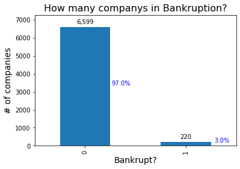

```python
plot_class_distribution(0,"How many companys in Bankruption?")
```

The samples are not balanced in terms of class. Indeed, 6.599 samples belong to class 0 and only 220 to class 1 (companies in bankruption). This should be accounted for when splitting the data between training and testing data (it is useful to use the stratify option available within sklearn.model_selection.train_test_split).

Understanding the distribution of all variables:

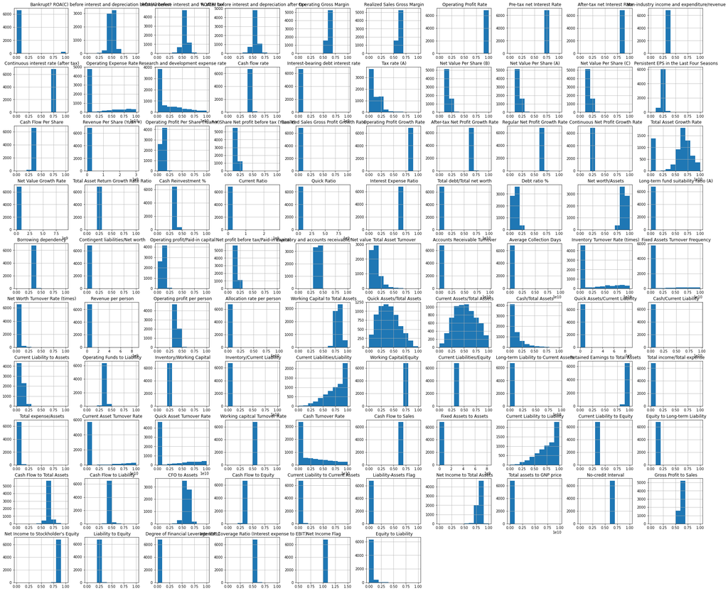

```python
df.hist(bins=10, figsize=(35,30))
plt.show()
```

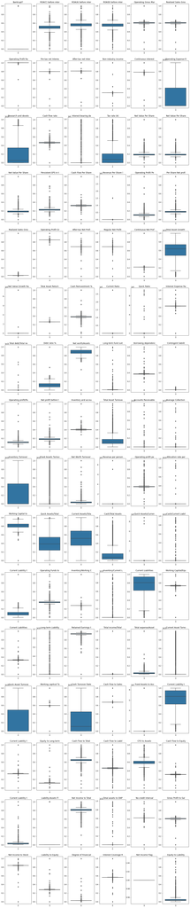

```python
fig, axs=plt.subplots(16, 6, figsize=(20,100), sharey=False)

for i in range (0,16):
    for j in range (0,6):
        sns.boxplot(data=df.iloc[:,6*i+j],ax=axs[i, j])
        axs[i,j].set_title(df.iloc[:,6*i+j].name[0:20])
```

## Identifying outliers

In this section, we intent to identify the outliers and eliminate them to avoid distort statistical analyses.

```python
# Identifying outliers
df_stat = df.describe()
iqr = df_stat.iloc[6,:]-df_stat.iloc[4,:]
lim_min = df_stat.iloc[4,:] - (1.5 * iqr)
lim_max = df_stat.iloc[6,:] + (1.5 * iqr)
min = df_stat.iloc[3,:]
max = df_stat.iloc[7,:]
```

```python
df_stat = pd.DataFrame()
df_stat ['lim_min_out'] = lim_min
df_stat ['min_data'] = min
df_stat ['lim_max_out'] = lim_max
df_stat ['max_data'] = max

df_stat
```

|  | lim_min_out | min_data | lim_max_out | max_data |
| --- | --- | --- | --- | --- |
| Bankrupt? | 0.000000 | 0.0 | 0.000000 | 1.0 |
| ROA(C) before interest and depreciation before interest | 0.387973 | 0.0 | 0.624116 | 1.0 |
| ROA(A) before interest and % after tax | 0.455122 | 0.0 | 0.669579 | 1.0 |
| ROA(B) before interest and depreciation after tax | 0.442034 | 0.0 | 0.669348 | 1.0 |
| Operating Gross Margin | 0.580240 | 0.0 | 0.634118 | 1.0 |
| ... | ... | ... | ... | ... |
| Liability to Equity | 0.270187 | 0.0 | 0.288207 | 1.0 |
| Degree of Financial Leverage (DFL) | 0.026608 | 0.0 | 0.027096 | 1.0 |
| Interest Coverage Ratio (Interest expense to EBIT) | 0.564309 | 0.0 | 0.566574 | 1.0 |
| Net Income Flag | 1.000000 | 1.0 | 1.000000 | 1.0 |
| Equity to Liability | -0.018065 | 0.0 | 0.095380 | 1.0 |

96 rows × 4 columns

Although many results are outside the limits calculated (Q1-1,5*IQR,Q3+1,5*IQR) most of them probably are not outliers. Only companies that show results different from the majority.

**Data below the minimum limit:**

As there are a lot of companies with financial indicators equal to zero, we will try to understand the situation from a more quantitative perspective. It can be useful to count the occurrences of zeros for each feature, and sort them in descending order. This allows us to establish the dominance level for zero entries.

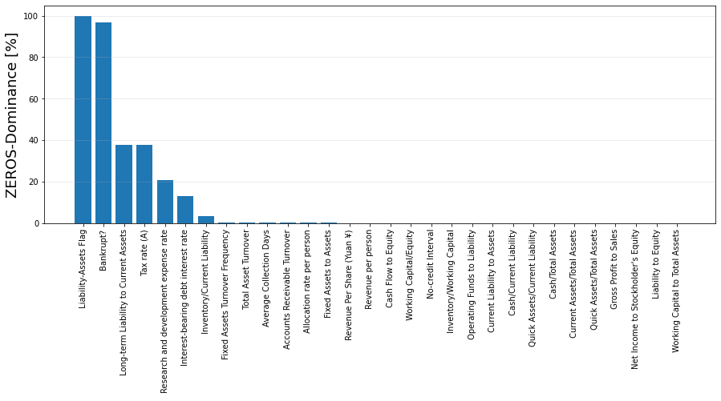

```python
total_zeros = df.isin([0]).sum().sort_values(ascending=False)
percent_zeros = (df.isin([0]).sum()/df.isin([0]).count() * 100).sort_values(ascending=False)
df_zeros = pd.concat([total_zeros, percent_zeros], axis=1, keys=['Total Zeros', 'Percent Zeros'])

# Graphical representation

plt.figure(figsize=(15,5))
plt.bar(np.arange(30), df_zeros['Percent Zeros'].iloc[:30].values.tolist())
plt.xticks(np.arange(30), df_zeros['Percent Zeros'].iloc[:30].index.values.tolist(), rotation='90')
plt.ylabel('ZEROS-Dominance [%]', fontsize=18)
plt.grid(alpha=0.3, axis='y')
plt.show()
```

The first two features are categorical data (class 0 and 1), they are not outliers.

Apparently, possibly the other indicators can also not be outliers. For example:

- The indicator "long-term liabilities" represents financial obligations of a company that are due more than one year in the future. Therefore, probably the companies whose indicator is zero do not have long-term liabilities.
- Also the companies which the indicator "research and development expense rate" is equal to zero, probably, not incurs R&D expenses in the process of finding and creating new products or services.
- Companies that do not have inventory, will have the indicator "inventory/current Liability" equal to zero.

Similar explanations can be done for the others indicators.

**Data above the maximum limit:**

When we look for the boxplots generated (see the previous section), we can observe that many of the indicators that have data above the maximum limit are related to rates. These rates can have high values when divided by numbers close to zero.

**Considerations:**

We could not remove data considering the limits calculated (Q1-1,5 IQR, Q3+1,5 IQR), looking only for each feature individually. The data seems reasonable and consistent. Maybe, we could try to identify if there are some outliers analysing clusters.

To optimize time, whe decided select the features, create and run the models and see how these data will affect the model. Them we define how to deal with it.

## Correlations between the indicators

Correlation Between Bankrupt and the other features:

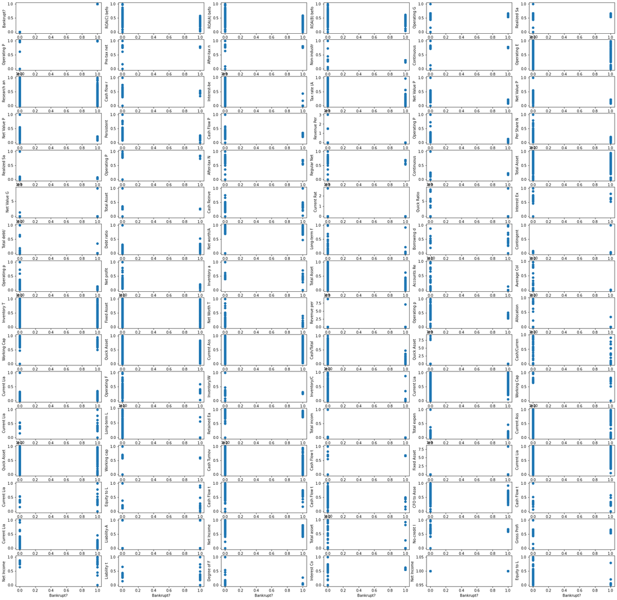

```python
def plot_correlations(df):
# Plotting graphics with correlations between bankrupt and features

    fig, axs = plt.subplots(16, 6, figsize=(30,30), sharey=False)

    for i in range (0,16):
        for j in range (0,6):
            axs[i,j].scatter(df.iloc[:,0].values,df.iloc[:,6*i+j].values)
            axs[i,j].set(xlabel=df.iloc[:,0].name, ylabel = df.iloc[:,6*i+j].name[0:12])

plot_correlations(df)
```

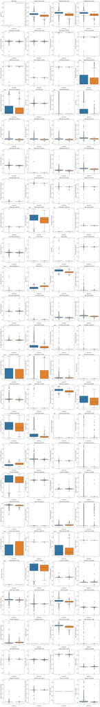

```python
fig, axs=plt.subplots(24, 4, figsize=(20,150), sharey=False)

for i in range(0,24):
    for j in range(0,4):
        sns.boxplot(x=df.iloc[:,0], y=df.iloc[:,4*i+j], ax=axs[i, j])
        axs[i,j].set(title=df.iloc[:,4*i+j].name[0:20])
```

The Pearson correlation evaluates the linear relationship between two continuous variables.

The Spearman correlation coefficient is based on the ranked values for each variable rather than the raw data. It is often used to evaluate relationships involving ordinal variables.

We will use Pearson correlation to observe the results among the features and Spearman correlation to the binary features (as bankrupt, for example).

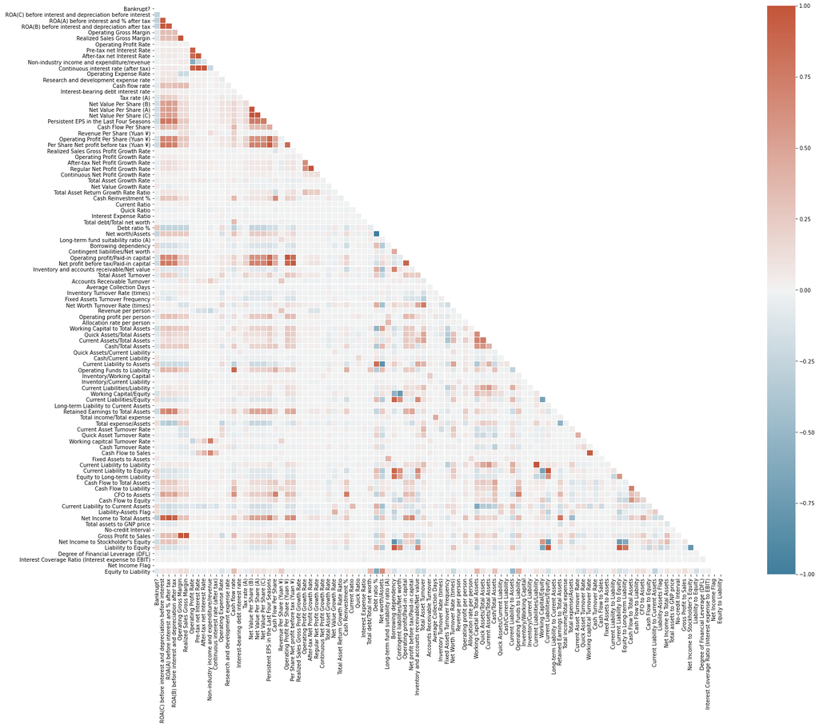

```python
f, ax = plt.subplots(figsize=(30, 20))

corr_num = df.corr('pearson')
corr_ord = df.corr('spearman')

cmap = sns.diverging_palette(230, 20, as_cmap=True)

matrix = np.triu(np.ones_like(corr_num, dtype=bool))
            # np.triu => return a copy of an array with the elements below the k-th diagonal zeroed.

sns.heatmap(corr_num, mask=matrix, vmin=-1, vmax=1, center=0,cmap=cmap, square=True, linewidths=.1)
            # annot=True # to show the values
            # mask: data are not shown in cells where mask is True.

plt.show()
```

We will used the correlation matrix, for 2 reasons:

- To eliminate features that do not have corrrelation with the bankrupt feature.
- To see features that have good correlation and should not be considered together.

## Partition the data in training and testing

**Stratified Train-Test Splits**

Our classification problems do not have a balanced number of examples for each class label. As such, it is desirable to split the dataset into train and test sets in a way that preserves the same proportions of examples in each class as observed in the original dataset.

We can achieve this by setting the “stratify” argument to the y component of the original dataset. This will be used by the train_test_split() function to ensure that both the train and test sets have the proportion of examples in each class that is present in the provided “y” array.

```python
X = df.iloc[:,1:]
y = df.iloc[:,0]
```

```python
# split into train test sets
X_train, X_test, y_train, y_test = train_test_split (X, y, test_size=0.40, random_state=1, stratify=y)
```

```python
print(f"y_train = {Counter (y_train)}")
print(f"                   0: {Counter(y_train)[0]/len(y_train):.0%},  1: {Counter(y_train)[1]/len(y_train):.0%}")
print()
print(f"y_test = {Counter (y_test)}")
print(f"                  0: {Counter(y_test)[0]/len(y_test):.0%},  1: {Counter(y_test)[1]/len(y_test):.0%}")
```

```
y_train = Counter({0: 3959, 1: 132})
                   0: 97%,  1: 3%

y_test = Counter({0: 2640, 1: 88})
                  0: 97%,  1: 3%
```

## Selecting the main features

Performe feature analyses to determine the most influential features, eliminating redundant or less relevant ones.

Three benefits of performing feature selection before modeling your data are:

- Reduces Overfitting: Less redundant data means less opportunity to make decisions based on noise.
- Improves Accuracy: Less misleading data means modeling accuracy improves.
- Reduces Training Time: Less data means that algorithms train faster.

To select the features we will ranking the features based in tree-based estimators (decision trees) and RFECV.

Although selecting features based on decision trees already consider correlations, we will calculate these parameters separately to help us in the analysis.

### Feature selection using SelectFromModel¶

SelectFromModel is a meta-transformer that can be used with an estimator to select features based in your importance (feature*importances*). Other features are desconsidered and removed if the corresponding importance of them are below the provided threshold parameter (“median”). It is possible also use the max_features parameter to set a limit of the number of features to select.

### Tree-based feature selection¶

Tree-based estimators can be used to compute impurity-based feature importances, which in turn can be used to discard irrelevant features (when coupled with the SelectFromModel meta-transformer):

```python
def tree_based_feature_selection(X, y):

    from pandas.core.common import flatten

    seed(1)
    clf = DecisionTreeClassifier()
    clf = clf.fit(X, y)
    df_feat_importance = pd.DataFrame(clf.feature_importances_, index=X.columns, columns=['feat_importance'])

    selector = SelectFromModel(clf, threshold='median')
    X_new = selector.fit_transform(X, y)
    # [trans.get_support]: Get a mask, or integer index, of the features selected
    df_feat_retained_decision_tree = pd.DataFrame(X.columns[selector.get_support()].values,columns=['features'])

    data = {'features':X.columns.values,
            'importance':clf.feature_importances_,
            'select_tree': selector.get_support()}

    df_tree = pd.DataFrame(data)

    return df_feat_importance, df_feat_retained_decision_tree, df_tree

df_feat_importance, df_feat_retained_decision_tree, df_tree = tree_based_feature_selection(X_train, y_train)
```

Features importance:

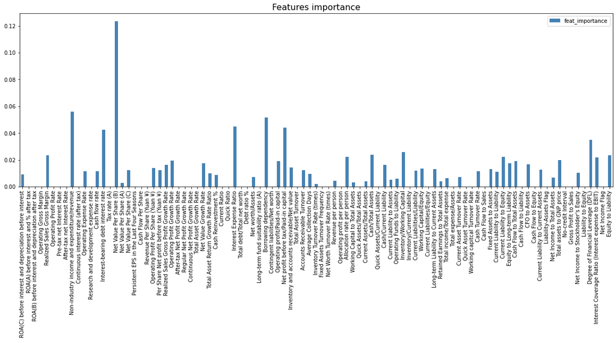

```python
df_feat_importance.plot.bar(color='steelblue', figsize=(20, 6))
plt.title ("Features importance", fontsize=16);
```

Features selected after to run the model (decision tree):

```python
print('Features selected decision tree:')
print("Started with: {0} features".format(X.shape[1]))
print("Retained:     {0} features".format(len(df_feat_retained_decision_tree)));
```

```
Features selected decision tree:
Started with: 95 features
Retained:     48 features
```

```python
df_feat_retained_decision_tree
```

|  | features |
| --- | --- |
| 0 | Realized Sales Gross Margin |
| 1 | Operating Profit Rate |
| 2 | Pre-tax net Interest Rate |
| 3 | Non-industry income and expenditure/revenue |
| 4 | Operating Expense Rate |
| ... | ... |
| 43 | No-credit Interval |
| 44 | Net Income to Stockholder's Equity |
| 45 | Degree of Financial Leverage (DFL) |
| 46 | Interest Coverage Ratio (Interest expense to ... |
| 47 | Equity to Liability |

48 rows × 1 columns

Consolidating data in a database:

```python
pd.set_option('display.max_rows', None)
df_tree.sort_values(by=['importance'], ascending=False)
```

|  | features | importance | select_tree |
| --- | --- | --- | --- |
| 15 | Net Value Per Share (B) | 0.123288 | True |
| 8 | Non-industry income and expenditure/revenue | 0.056084 | True |
| 39 | Borrowing dependency | 0.051679 | True |
| 34 | Interest Expense Ratio | 0.045004 | True |
| 42 | Net profit before tax/Paid-in capital | 0.044164 | True |
| 13 | Interest-bearing debt interest rate | 0.042330 | True |
| 91 | Degree of Financial Leverage (DFL) | 0.034816 | True |
| 61 | Inventory/Working Capital | 0.025644 | True |
| 56 | Cash/Total Assets | 0.023681 | True |
| 4 | Realized Sales Gross Margin | 0.023414 | True |
| 94 | Equity to Liability | 0.023379 | True |
| 77 | Current Liability to Equity | 0.022269 | False |
| 52 | Allocation rate per person | 0.022251 | True |
| 92 | Interest Coverage Ratio (Interest expense to ... | 0.021981 | True |
| 86 | Total assets to GNP price | 0.019882 | True |
| 24 | Operating Profit Growth Rate | 0.019404 | False |
| 79 | Cash Flow to Total Assets | 0.019072 | False |
| 41 | Operating profit/Paid-in capital | 0.018900 | False |
| 78 | Equity to Long-term Liability | 0.017396 | True |
| 29 | Net Value Growth Rate | 0.017380 | True |
| 81 | CFO to Assets | 0.016537 | False |
| 23 | Realized Sales Gross Profit Growth Rate | 0.016353 | True |
| 58 | Cash/Current Liability | 0.016338 | True |
| 43 | Inventory and accounts receivable/Net value | 0.014091 | True |
| 21 | Operating Profit Per Share (Yuan ¥) | 0.014008 | False |
| 64 | Working Capital/Equity | 0.013418 | False |
| 66 | Long-term Liability to Current Assets | 0.013210 | False |
| 75 | Fixed Assets to Assets | 0.012940 | False |
| 83 | Current Liability to Current Assets | 0.012525 | True |
| 45 | Accounts Receivable Turnover | 0.012340 | True |

[output cut: 65 more lines]

Explanation to features high importance do not match with the selected ones...

### Recursive feature elimination

Given an external estimator that assigns weights to features, the goal of recursive feature elimination (RFE) is to select features by recursively considering smaller and smaller sets of features. First, the estimator is trained on the initial set of features and the importance of each feature is obtained either through any specific attribute (such as coef_, feature*importances*) or callable. Then, the least important features are pruned from current set of features. That procedure is recursively repeated on the pruned set until the desired number of features to select is eventually reached (Skit-learn).

RFECV performs RFE in a cross-validation loop to find the optimal number of features.

```python
def tree_rfecv_feature_selection(X, y):

    seed(1)
    clf = DecisionTreeClassifier()
    trans = RFECV(clf)
    X_new = trans.fit_transform(X, y)

    df_feat_retained_rfecv = pd.DataFrame(X.columns[trans.get_support()].values, columns = ['features'])

    data = {'features':X.columns.values,
             'rank_rfecv':trans.ranking_,
             'selected_rfecv': trans.support_}

    df_rfecv = pd.DataFrame(data)

    return df_feat_retained_rfecv, df_rfecv

df_feat_retained_rfecv, df_rfecv = tree_rfecv_feature_selection(X_train, y_train)
```

Features selected after to run the model (RFECV - decision tree):

```python
print('Features selected RFECV - decision tree:')
print("Started with: {0} features".format(X.shape[1]))
print("Retained:     {0} features".format(len(df_feat_retained_rfecv)))
```

```
Features selected RFECV - decision tree:
Started with: 95 features
Retained:     21 features
```

```python
df_feat_retained_rfecv
```

|  | features |
| --- | --- |
| 0 | Non-industry income and expenditure/revenue |
| 1 | Operating Expense Rate |
| 2 | Research and development expense rate |
| 3 | Interest-bearing debt interest rate |
| 4 | Net Value Per Share (B) |
| 5 | Net Value Growth Rate |
| 6 | Cash Reinvestment % |
| 7 | Interest Expense Ratio |
| 8 | Net worth/Assets |
| 9 | Borrowing dependency |
| 10 | Net profit before tax/Paid-in capital |
| 11 | Inventory Turnover Rate (times) |
| 12 | Allocation rate per person |
| 13 | Current Assets/Total Assets |
| 14 | Cash/Total Assets |
| 15 | Inventory/Working Capital |
| 16 | Quick Asset Turnover Rate |
| 17 | Current Liability to Current Assets |
| 18 | Total assets to GNP price |
| 19 | Net Income to Stockholder's Equity |
| 20 | Degree of Financial Leverage (DFL) |

Consolidating data in a database:

```python
df_feat = pd.merge(df_tree, df_rfecv, how="left")
```

```python
df_feat
```

|  | features | importance | select_tree | rank_rfecv | selected_rfecv |
| --- | --- | --- | --- | --- | --- |
| 0 | ROA(C) before interest and depreciation befor... | 0.008929 | False | 75 | False |
| 1 | ROA(A) before interest and % after tax | 0.000000 | False | 74 | False |
| 2 | ROA(B) before interest and depreciation after... | 0.000000 | False | 71 | False |
| 3 | Operating Gross Margin | 0.000000 | False | 70 | False |
| 4 | Realized Sales Gross Margin | 0.023414 | True | 69 | False |
| 5 | Operating Profit Rate | 0.000000 | True | 67 | False |
| 6 | Pre-tax net Interest Rate | 0.000000 | True | 66 | False |
| 7 | After-tax net Interest Rate | 0.000000 | False | 65 | False |
| 8 | Non-industry income and expenditure/revenue | 0.056084 | True | 1 | True |
| 9 | Continuous interest rate (after tax) | 0.000000 | False | 25 | False |
| 10 | Operating Expense Rate | 0.011438 | True | 1 | True |
| 11 | Research and development expense rate | 0.000000 | False | 1 | True |
| 12 | Cash flow rate | 0.011352 | False | 23 | False |
| 13 | Interest-bearing debt interest rate | 0.042330 | True | 1 | True |
| 14 | Tax rate (A) | 0.000000 | False | 19 | False |
| 15 | Net Value Per Share (B) | 0.123288 | True | 1 | True |
| 16 | Net Value Per Share (A) | 0.002625 | True | 21 | False |
| 17 | Net Value Per Share (C) | 0.012194 | False | 2 | False |
| 18 | Persistent EPS in the Last Four Seasons | 0.000000 | False | 42 | False |
| 19 | Cash Flow Per Share | 0.000000 | False | 28 | False |
| 20 | Revenue Per Share (Yuan ¥) | 0.000000 | False | 43 | False |
| 21 | Operating Profit Per Share (Yuan ¥) | 0.014008 | False | 39 | False |
| 22 | Per Share Net profit before tax (Yuan ¥) | 0.012134 | True | 57 | False |
| 23 | Realized Sales Gross Profit Growth Rate | 0.016353 | True | 33 | False |
| 24 | Operating Profit Growth Rate | 0.019404 | False | 15 | False |
| 25 | After-tax Net Profit Growth Rate | 0.000000 | True | 37 | False |
| 26 | Regular Net Profit Growth Rate | 0.000000 | False | 50 | False |
| 27 | Continuous Net Profit Growth Rate | 0.000000 | True | 51 | False |
| 28 | Total Asset Growth Rate | 0.000000 | True | 54 | False |
| 29 | Net Value Growth Rate | 0.017380 | True | 1 | True |

[output cut: 65 more lines]

We can observe that using this recourse already remove features high correlated between them.

### Correlated features

We will include in the dataframe the correlations among the features and the Bankrupt variable. These correlations have already been considered in the previous analyzes of tree-based feature selection and recursive feature elimination. We will include these data only for a better understanding of the features and validations of analyzes.

```python
df_feat_correlation_y = pd.DataFrame(abs(corr_ord["Bankrupt?"])).reset_index()
df_feat_correlation_y = df_feat_correlation_y.rename(columns = {'index':'features', 'Bankrupt?': 'corr'})
```

```python
df_feat = pd.merge(df_feat, df_feat_correlation_y, how="left")
```

Features to be excluded:

- Net income flag (all companies with the same value)

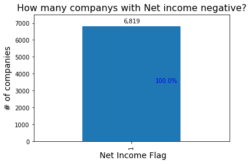

```python
plot_class_distribution(94,"How many companys with Net income negative?")
```

#### Database wih the features selected

```python
df_feat = df_feat.sort_values(by= 'rank_rfecv')
```

```python
df_feat
```

|  | features | importance | select_tree | rank_rfecv | selected_rfecv | corr |
| --- | --- | --- | --- | --- | --- | --- |
| 47 | Inventory Turnover Rate (times) | 0.001875 | True | 1 | True | 0.012556 |
| 71 | Quick Asset Turnover Rate | 0.000000 | True | 1 | True | 0.036946 |
| 61 | Inventory/Working Capital | 0.025644 | True | 1 | True | 0.055539 |
| 56 | Cash/Total Assets | 0.023681 | True | 1 | True | 0.150828 |
| 55 | Current Assets/Total Assets | 0.003832 | True | 1 | True | 0.044232 |
| 52 | Allocation rate per person | 0.022251 | True | 1 | True | 0.092368 |
| 42 | Net profit before tax/Paid-in capital | 0.044164 | True | 1 | True | 0.233106 |
| 39 | Borrowing dependency | 0.051679 | True | 1 | True | 0.215094 |
| 37 | Net worth/Assets | 0.007176 | False | 1 | True | 0.217237 |
| 34 | Interest Expense Ratio | 0.045004 | True | 1 | True | 0.133217 |
| 31 | Cash Reinvestment % | 0.008533 | True | 1 | True | 0.091397 |
| 29 | Net Value Growth Rate | 0.017380 | True | 1 | True | 0.203438 |
| 15 | Net Value Per Share (B) | 0.123288 | True | 1 | True | 0.205633 |
| 83 | Current Liability to Current Assets | 0.012525 | True | 1 | True | 0.189552 |
| 13 | Interest-bearing debt interest rate | 0.042330 | True | 1 | True | 0.116011 |
| 89 | Net Income to Stockholder's Equity | 0.010218 | True | 1 | True | 0.219057 |
| 91 | Degree of Financial Leverage (DFL) | 0.034816 | True | 1 | True | 0.147136 |
| 86 | Total assets to GNP price | 0.019882 | True | 1 | True | 0.055114 |
| 8 | Non-industry income and expenditure/revenue | 0.056084 | True | 1 | True | 0.204846 |
| 10 | Operating Expense Rate | 0.011438 | True | 1 | True | 0.009967 |
| 11 | Research and development expense rate | 0.000000 | False | 1 | True | 0.038467 |
| 17 | Net Value Per Share (C) | 0.012194 | False | 2 | False | 0.203778 |
| 53 | Working Capital to Total Assets | 0.002985 | True | 3 | False | 0.173154 |
| 65 | Current Liabilities/Equity | 0.000000 | False | 4 | False | 0.182644 |
| 92 | Interest Coverage Ratio (Interest expense to ... | 0.021981 | True | 5 | False | 0.127470 |
| 50 | Revenue per person | 0.004300 | True | 6 | False | 0.020598 |
| 78 | Equity to Long-term Liability | 0.017396 | True | 7 | False | 0.117302 |
| 30 | Total Asset Return Growth Rate Ratio | 0.009785 | False | 8 | False | 0.105163 |
| 45 | Accounts Receivable Turnover | 0.012340 | True | 9 | False | 0.023694 |
| 58 | Cash/Current Liability | 0.016338 | True | 10 | False | 0.146753 |

[output cut: 65 more lines]

```python
df_feat.to_csv('./data/bankruptcy.csv')
```